# Comparación de gráficas (Primer trabajo en grupo)

Equipo TF5

26 de enero de 2022

# Presentación

- Estadística Descriptiva y Análisis Exploratorio de Datos
- Universidad Nacional de Colombia sede Medellín
- Semestre 2021-02

### Miembros del equipo

- Andrés Felipe Aparicio Mestre
- Emmanuel López Rodríguez
- José David Cardona Soto
- Jerónimo Gómez Restrepo
- Samuel Alahín López Cadavid

# Introducción y contextualización

En el articulo titulado [La minería: un debate entre el riesgo y su aporte](https://www.elcolombiano.com/negocios/economia/mineria-que-tanto-afecta-al-medioambiente-EB13561207) del periódico el Colombiano, aseguran que promover la minería legal en Colombia traerá mayores empleos para la población, mayor inversión en el país y numerosos ingresos económicos gracias a la actividad extractiva minera. Durante años se ha creído que la minería trae consigo grandes afectaciones ambientales, por la contaminación de fuentes hídricas y del suelo, y a partir de esto afectaciones para la salud, sin embargo profesores y geólogos aseguran que estás afirmaciones son falsas, ya que con el avance tecnológico de hoy en día, estas afectaciones son mitigadas y el impacto ambiental es casi nulo.

En el documento se muestra un gráfico de cubos y círculos, el cuál provee información acerca de la producción esperada (En toneladas) de mineral, los empleos generados y los ingresos anuales por regalías e impuestos anuales para el país (en US$ millones), en algunas minas importantes del país las cuales son: El Cerrejón, La Jagua, Centro del Cesar y Cerromatoso. De esta forma se argumenta la promoción de la minería.

Inicialmente se les presentó a los estudiantes dos gráficos, solo con el valor de la producción esperada o de las regalías de la mina El Cerrejón, y a partir de este valor debían de estimar a ojo el correspondiente valor para las demás minas.

Una de las gráficas correspondía a la producción esperada y la otra a las regalías e impuestos anuales. Las gráficas podían ser de los siguientes 5 tipos: círculos y cubos, barras verticales, pasteles, pasteles 3D y barras horizontales. Se hizo la recolección de las respuestas de los estudiantes, y a partir de estos datos se debía realizar un análisis exploratorio. A continuación se muestran algunos registros de la base de datos original:

| Enviado | Completado | Q1 | Q2 | Q3 | Q4 | Q5 | Q6 | Grupo |
| --- | --- | --- | --- | --- | --- | --- | --- | --- |
| 15/12/2021 09:08:48 | y | 9.3 | 43.0 | 1.0 | 140 | 970 | 140 | 5 |
| 15/12/2021 09:04:08 | y | 10.0 | 38.0 | 1.0 | 100 | 940 | 100 | 1 |
| 15/12/2021 09:06:00 | y | 13.0 | 58.0 | 2.0 | 200 | 1080 | 160 | 4 |
| 15/12/2021 09:14:49 | y | 15.0 | 55.0 | 3.0 | 410 | 1300 | 380 | 4 |
| 15/12/2021 09:07:08 | y | 6.0 | 52000.0 | 1.0 | 90 | 800 | 90 | 1 |
| 15/12/2021 09:13:15 | y | 11.5 | 38.9 | 0.5 | 150 | 1020 | 150 | 3 |

*Cabe recalcar que por la estética del informe se cambiaron los nombres de las columnas de la base de datos original antes de imprimirla*

### Siglas utilizadas

- **Q1:** Se refiere a la respuesta de la pregunta 1
- **Q2:** Se refiere a la respuesta de la pregunta 2
- **Q3:** Se refiere a la respuesta de la pregunta 3
- **Q4:** Se refiere a la respuesta de la pregunta 4
- **Q5:** Se refiere a la respuesta de la pregunta 5
- **Q6:** Se refiere a la respuesta de la pregunta 6

# Depuración de la base de datos

Como podemos observar en la base de datos original se cuentan con 9 columnas, pero llegamos a la conclusión que para el estudio que se va a realizar a partir de esta, son inservibles 2 de ellas. Las columnas que eliminaremos son:

- **Enviado:** Que nos dice la hora a la cual el estudiante envió sus respuestas al sistema, en este estudio no nos enfocaremos en el tiempo que les tomó a los estudiantes responder, si no en sus respuestas.
- **Completado:** Que nos indica si el estudiante envió sus respuestas al sistema. En esta columna todos los estudiantes tienen el valor de *“y”*, el cual indica que enviaron la prueba, por lo que no nos es relevante esta información.

También, notamos que una de las filas de la base de datos contenía solo uno de sus campos con información, el resto estaban vacíos *(Valor NA)*. Por tanto decidimos eliminarla.

Posteriormente, decidimos por cambiar el nombre de las columnas que nos quedaban. Esto, para facilitarnos el trabajo a la hora de necesitar referenciarlas dentro del código.

Por último, optamos por mover la columna **“Grupo”** al primer lugar de la base de datos, ya que próximamente será una variable muy importante dentro del estudio

| Grupo | Q1_LaJagua | Q2_CentroDelCesar | Q3_Cerromatoso | Q4_LaJagua | Q5_CentroDelCesar | Q6_Cerromatoso |
| --- | --- | --- | --- | --- | --- | --- |
| 5 | 9.3 | 43.0 | 1.0 | 140 | 970 | 140 |
| 1 | 10.0 | 38.0 | 1.0 | 100 | 940 | 100 |
| 4 | 13.0 | 58.0 | 2.0 | 200 | 1080 | 160 |
| 4 | 15.0 | 55.0 | 3.0 | 410 | 1300 | 380 |
| 1 | 6.0 | 52000.0 | 1.0 | 90 | 800 | 90 |
| 3 | 11.5 | 38.9 | 0.5 | 150 | 1020 | 150 |

### Corrección de datos atípicos

Ahora, notamos que dentro de las respuestas de los estudiantes existen datos atípicos que, de no ser tratados afectarán nuestras conclusiones del estudio. Para mostrar esto, haremos un *Summary* de la base de datos

```
##      Grupo         Q1_LaJagua       Q2_CentroDelCesar  Q3_Cerromatoso        Q4_LaJagua
##  Min.   :1.000   Min.   :       6   Min.   :       0   Min.   :      0.0   Min.   :   48.0
##  1st Qu.:2.000   1st Qu.:       8   1st Qu.:      35   1st Qu.:      0.1   1st Qu.:  120.0
##  Median :3.000   Median :      10   Median :      40   Median :      1.0   Median :  142.0
##  Mean   :2.938   Mean   :  206260   Mean   :  619602   Mean   :  20627.3   Mean   :  390.5
##  3rd Qu.:4.000   3rd Qu.:      12   3rd Qu.:      51   3rd Qu.:      1.7   3rd Qu.:  180.0
##  Max.   :5.000   Max.   :13200000   Max.   :39600000   Max.   :1320000.0   Max.   :15000.0
##  Q5_CentroDelCesar Q6_Cerromatoso
##  Min.   :   90.0   Min.   :  48.0
##  1st Qu.:  847.5   1st Qu.: 120.0
##  Median :  952.5   Median : 144.0
##  Mean   : 1663.3   Mean   : 259.1
##  3rd Qu.: 1001.0   3rd Qu.: 180.0
##  Max.   :50000.0   Max.   :4000.0
```

Como se puede observar, hay estudiantes que suministraron los datos en proporciones erroneas. Durante el transcurso de la prueba, se indicó que los datos en millones se debían de escribir de manera resumida *(Ejemplo: “26.4” en lugar de “26’400.000”)* y los datos con parte fraccionaria debían ser separados con punto, sin embargo, algunos estudiantes hicieron caso omiso de las indicaciones, por lo que se presentan datos atípicos muy grandes en comparación a la media de la columna. Tratamos esos datos dándoles una proporción que los ajustara mucho mejor a la media de la columna.

También, notamos casos puntuales donde se trucaba la respuesta de una pregunta con otra sucesiva a ella *(Ejemplo: Respuesta de Q2 en Q3 y viceversa)*, por lo que para no desperdiciar los datos de estos estudiantes, optamos por mover manualmente los valores entre columnas en los que al hacer el análisis calzaban perfectamente dentro de la media.

Luego de hacer toda la depuración, observaremos de nuevo el *Summary* de la base de datos corregida. Donde se puede analizar que ahora los datos extremos de cada columna están mucho más cerca entre si y la media de las columnas es un valor mucho más realista.

```
##      Grupo         Q1_LaJagua    Q2_CentroDelCesar Q3_Cerromatoso    Q4_LaJagua
##  Min.   :1.000   Min.   : 6.00   Min.   :30.00     Min.   :0.000   Min.   : 48.0
##  1st Qu.:2.000   1st Qu.: 8.15   1st Qu.:36.94     1st Qu.:0.100   1st Qu.:120.0
##  Median :3.000   Median :10.00   Median :40.00     Median :1.000   Median :142.0
##  Mean   :2.938   Mean   :10.53   Mean   :43.63     Mean   :1.054   Mean   :158.5
##  3rd Qu.:4.000   3rd Qu.:12.25   3rd Qu.:50.00     3rd Qu.:1.305   3rd Qu.:172.5
##  Max.   :5.000   Max.   :23.00   Max.   :79.20     Max.   :5.000   Max.   :410.0
##  Q5_CentroDelCesar Q6_Cerromatoso
##  Min.   : 500.0    Min.   : 40.0
##  1st Qu.: 860.5    1st Qu.:120.0
##  Median : 957.5    Median :142.0
##  Mean   : 941.6    Mean   :159.6
##  3rd Qu.:1001.0    3rd Qu.:172.5
##  Max.   :1440.0    Max.   :380.0
```

La base de datos depurada. Nos queda de la siguiente manera:

| Grupo | Q1_LaJagua | Q2_CentroDelCesar | Q3_Cerromatoso | Q4_LaJagua | Q5_CentroDelCesar | Q6_Cerromatoso |
| --- | --- | --- | --- | --- | --- | --- |
| 5 | 9.3 | 43.0 | 1.0 | 140 | 970 | 140 |
| 1 | 10.0 | 38.0 | 1.0 | 100 | 940 | 100 |
| 4 | 13.0 | 58.0 | 2.0 | 200 | 1080 | 160 |
| 4 | 15.0 | 55.0 | 3.0 | 410 | 1300 | 380 |
| 1 | 6.0 | 52.0 | 1.0 | 90 | 800 | 90 |
| 3 | 11.5 | 38.9 | 0.5 | 150 | 1020 | 150 |

# Comparación del desempeño en la percepción de las gráficas

4 **Tabla de las medias de los datos de cada pregunta en cada uno de los grupos:**

| Grupos | Q1 | Q2 | Q3 | Q4 | Q5 | Q6 |
| --- | --- | --- | --- | --- | --- | --- |
| 1 | 9.938462 | 43.75385 | 1.5961538 | 215.5385 | 910.1538 | 221.6923 |
| 2 | 9.657143 | 39.30000 | 0.7285714 | 141.8571 | 911.5714 | 142.7857 |
| 3 | 13.266667 | 47.39167 | 0.3958333 | 152.1667 | 994.3333 | 158.0000 |
| 4 | 10.642857 | 47.26786 | 1.7392857 | 152.3571 | 929.2857 | 144.3571 |
| 5 | 9.200000 | 40.23636 | 0.6727273 | 126.7273 | 975.0909 | 128.8182 |

**Tabla de las desviaciones estándar de los datos de cada pregunta en cada uno de los grupos:**

| Grupos | Q1 | Q2 | Q3 | Q4 | Q5 | Q6 |
| --- | --- | --- | --- | --- | --- | --- |
| 1 | 3.130905 | 14.207781 | 1.1668015 | 103.13471 | 182.71556 | 103.08280 |
| 2 | 1.278650 | 6.047504 | 0.6966166 | 37.20806 | 99.95362 | 37.84214 |
| 3 | 4.576289 | 8.788987 | 0.6319013 | 54.00645 | 68.35247 | 59.88018 |
| 4 | 3.371536 | 11.845343 | 1.1361505 | 83.26566 | 204.31741 | 77.91278 |
| 5 | 1.018823 | 3.921294 | 0.6325993 | 30.04693 | 84.61732 | 30.69143 |

[interactive chart not shown]

# Análisis de los resultados

Antes de hacer un análisis de los resultados es necesario tener presente lo siguiente:

- **Grupo 1**: Corresponde a la gráfica de círculos y cubos.

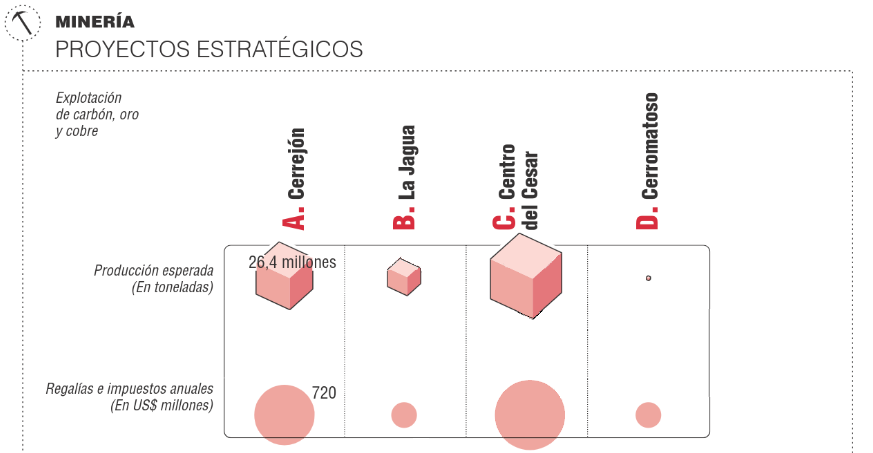

- **Grupo 2**: Corresponde a la gráfica de barras verticales.

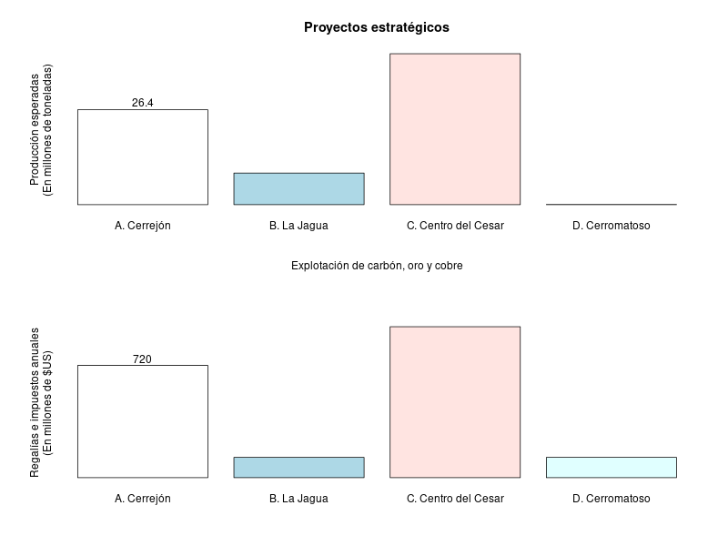

- **Grupo 3**: Corresponde a la gráfica de pasteles.

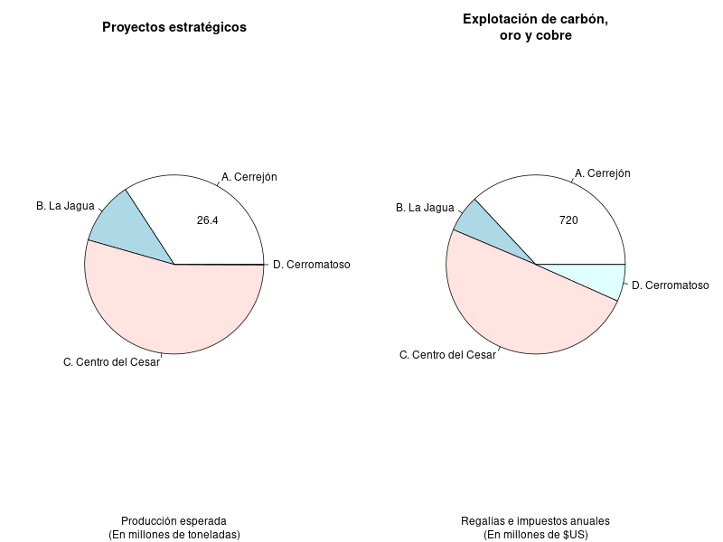

- **Grupo 4**: Corresponde a la gráfica de pasteles 3D.

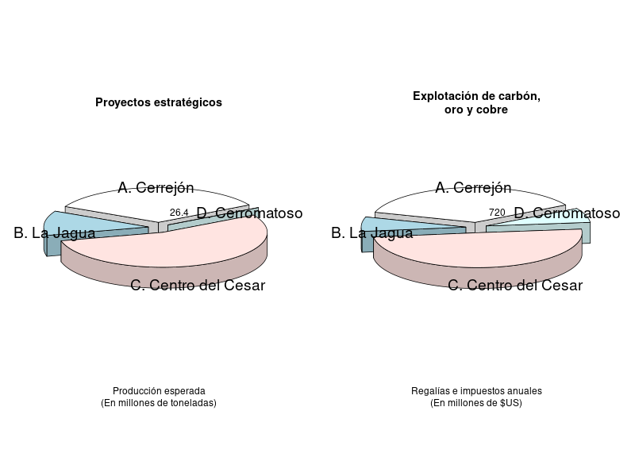

- **Grupo 5**: Corresponde a la gráfica de barra horizontales.

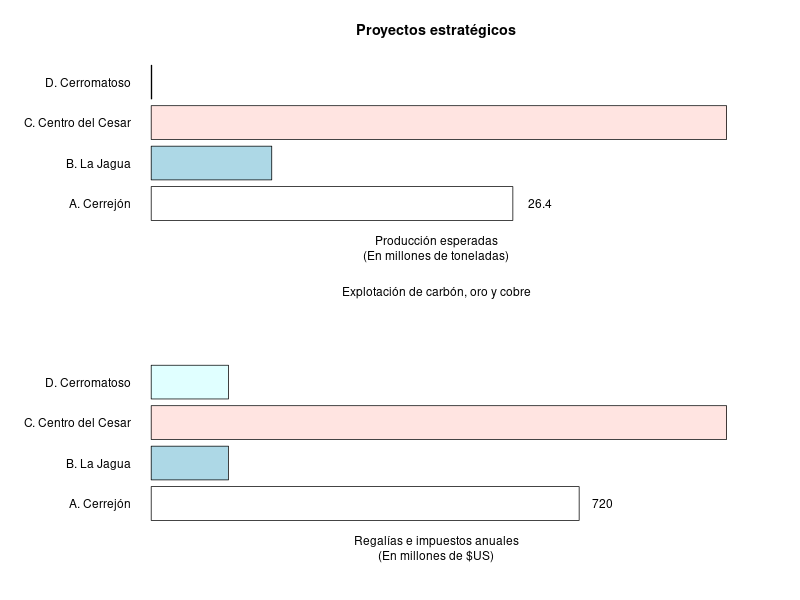

**Tabla de medias:**

| Grupos | Q1 | Q2 | Q3 | Q4 | Q5 | Q6 |
| --- | --- | --- | --- | --- | --- | --- |
| 1 | 9.938462 | 43.75385 | 1.5961538 | 215.5385 | 910.1538 | 221.6923 |
| 2 | 9.657143 | 39.30000 | 0.7285714 | 141.8571 | 911.5714 | 142.7857 |
| 3 | 13.266667 | 47.39167 | 0.3958333 | 152.1667 | 994.3333 | 158.0000 |
| 4 | 10.642857 | 47.26786 | 1.7392857 | 152.3571 | 929.2857 | 144.3571 |
| 5 | 9.200000 | 40.23636 | 0.6727273 | 126.7273 | 975.0909 | 128.8182 |

**Tabla de desviaciones:**

| Grupos | Q1 | Q2 | Q3 | Q4 | Q5 | Q6 |
| --- | --- | --- | --- | --- | --- | --- |
| 1 | 3.130905 | 14.207781 | 1.1668015 | 103.13471 | 182.71556 | 103.08280 |
| 2 | 1.278650 | 6.047504 | 0.6966166 | 37.20806 | 99.95362 | 37.84214 |
| 3 | 4.576289 | 8.788987 | 0.6319013 | 54.00645 | 68.35247 | 59.88018 |
| 4 | 3.371536 | 11.845343 | 1.1361505 | 83.26566 | 204.31741 | 77.91278 |
| 5 | 1.018823 | 3.921294 | 0.6325993 | 30.04693 | 84.61732 | 30.69143 |

A partir de la **tabla de las medias de los datos** y de **la tabla y gráficas de la desviación estándar**, se puede hacer el siguiente análisis:

Observando el [artículo original](https://www.elcolombiano.com/negocios/economia/mineria-que-tanto-afecta-al-medioambiente-EB13561207) podemos ver que los valores reales son:

[figure not shown]

| Grupos | Q1 | Q2 | Q3 | Q4 | Q5 | Q6 |
| --- | --- | --- | --- | --- | --- | --- |
| 1 | 1.1384615 | 1.753846 | 1.5521538 | 85.538461 | -57.846154 | 91.692308 |
| 2 | 0.8571429 | -2.700000 | 0.6845714 | 11.857143 | -56.428571 | 12.785714 |
| 3 | 4.4666667 | 5.391667 | 0.3518333 | 22.166667 | 26.333333 | 28.000000 |
| 4 | 1.8428571 | 5.267857 | 1.6952857 | 22.357143 | -38.714286 | 14.357143 |
| 5 | 0.4000000 | -1.763636 | 0.6287273 | -3.272727 | 7.090909 | -1.181818 |

La anterior tabla muestra la diferencia que hay entre la media respondida por cada grupo en cada una de las respuestas y el valor real que sacamos del estudio. Con base en esto podemos observar:

- **Para la pregunta 1:** El grupo que más se acercó al valor real fue el grupo 5 (Barras horizontales), mientras que el que más alejado estuvo fue el grupo 3 (Gráfica de pasteles 2D)
- **Para la pregunta 2:** Los grupos que más se acercaron al valor real fueron el grupo 1 (Cubos) y el grupo 5 (Barras horizontales). En el caso del grupo 1 la media respondió 1.75 millones por encima del valor real mientras que, en el caso del grupo 5 respondieron 1.76 millones por debajo del valor real. Los grupos que más se alejaron fueron: El grupo 3 (Gráfica de pasteles 2D) y el grupo 4 (Gráfica de pasteles 3D)
- **Para la pregunta 3:** El grupo que más se acercó al valor real fue el grupo 3 (Gráfica de pasteles 2D), mientras que el que más alejado estuvo fue el grupo 4 (Gráfica de pasteles 3D)
- **Para la pregunta 4:** El grupo que más se acercó al valor real fue el grupo 5 (Barras horizontales), mientras que el que más alejado estuvo fue el grupo 1 (Cubos y círculos)
- **Para la pregunta 5:** El grupo que más se acercó al valor real fue el grupo 5 (Barras horizontales), mientras que los que más alejados estuvieron fueron: el grupo 1 (Cubos y círculos) y el grupo 2 (Barras verticales)
- **Para la pregunta 6:** El grupo que más se acercó al valor real fue el grupo 5 (Barras horizontales), mientras que el que más alejado estuvo fue el grupo 1 (Cubos y círculos)

Se puede notar que para las 3 primeras preguntas (Acerca de la producción esperada), el grupo 5 (Barras horizontales) tuvo respuestas más cercanas al valor real mientras que los grupos 3 y 4 (Gráficas de pasteles) tuvieron respuestas más lejanas a los valores reales. Cabe resaltar que en la pregunta 3, los de mejor y peor desempeño fueron los grupos 3 y 4, (Pasteles 2D y pasteles 3D respectivamente).

Por otro lado para las preguntas 4, 5 y 6. La gráfica que más se acercó al valor real fue la del grupo 5 (Barras horizontales) y la gráfica que más se alejó del valor real fue la del grupo 1 (Cubos y círculos).

**La gráfica Q3**, puede ser una opción válida, aunque existen gráficas mejores como las anteriormente mencionadas, ya que estas poseen menor desviación estándar en la mayoría de preguntas, en comparación con el gráfico 3.

# Propuesta de experimento similar

Se presenta un experimento sobre los contagios de COVID 19. Como referencia tomamos la base de datos oficial proporcionada por el gobierno de Colombia con los datos actualizados hasta el 25 de enero de 2022. Proponemos hacer preguntas con base en diferentes gráficas que representen la cantidad de contagios discretizados en diferentes grupos (Sexo, edad, región, etc.). El objetivo del experimento es identificar cual es el tipo de gráfica que es más fácilmente comprendida por personas de diferentes edades, nivel académico, estrato, entre otros. Para esto, tomaremos muestras de diferentes poblaciones, puede ser por ejemplo niños de aproximadamente 10-11 años, personas que superan los 70-80 años o adultos jóvenes con nivel de estudio medio en distintas áreas del conocimiento que no necesariamente sean afines a la matemática o la estadística.

Con base en esto, el estudio pretende contestar preguntas del tipo: - ¿Cuál es el tipo de gráfica que es más fácilmente entendible entre todas las poblaciones? - ¿Cuál es el tipo de gráfica que es más fácilmente entendible para los niños? - ¿Cuál es el tipo de gráfica que es más fácilmente entendible para los adultos mayores? - ¿El nivel de estudios de una persona influye en su capacidad para comprender los distintos tipos de gráficas? - ¿Cuál es el rango de edad que tuvo mejor desempeño en la comprensión de las gráficas? - ¿Cuál fue el desempeño al comprender las gráficas de las personas en distintas áreas del conocimiento no afines a la matemáticas? ¿Fue mejor, peor o tuvieron el mismo desempeño? - Entre otras

Como se mencionó anteriormente, los datos que se utilizarán en el estudio se encuentran en el siguiente enlace de Datos Abiertos Colombia: [Casos positivos de COVID-19 en Colombia](https://www.datos.gov.co/Salud-y-Protecci-n-Social/Casos-positivos-de-COVID-19-en-Colombia/gt2j-8ykr)

# Conclusiones

A partir de los análisis realizados anteriormente, se llegan a las siguientes conclusiones:

1. **La pregunta 2**, que hace referencia a Centro del Cesar, presenta la **mayor dispersión de los datos**, lo que indica que **no** hubo una percepción **uniforme** por parte de los estudiantes en la **producción esperada**. Independientemente del tipo de gráfica utilizada.
2. **La pregunta 3**, que hace referencia a Cerromatoso, presenta la **menor dispersión de los datos**, lo que indica que la percepción de los estudiantes fue **uniforme en la producción esperada**. Independientemente del tipo de gráfica utilizada.
3. **La pregunta 5**, que hace referencia a Centro del Cesar, presenta la **mayor dispersión de los datos**, lo que indica que **no** hubo una percepción **uniforme** por parte de los estudiantes en **Regalías e impuestos**. Independientemente del tipo de gráfica utilizada.
4. **La pregunta 4**, que hace referencia a La Jagua, presenta la **menor dispersión de los datos**, lo que indica que la percepción de los estudiantes fue **uniforme en Regalías e impuestos**. Independientemente del tipo de gráfica utilizada.
5. Las gráficas de **barras verticales y horizontales**, generan percepciones **más uniformes**. Siendo la de **barras horizontales**, la que obtuvo respuestas **más similares**.
6. La gráfica de **circulos y cubos** junto con la de **pasteles 3D**, generan percepciones **más dispersas**. Siendo la de **circulos y cubos** la que obtuvo respuestas **menos uniformes**.
7. Las percepciones generadas con la gráfica de **barras horizontales**, son las **más cercanas al valor real**.
8. Las percepciones generadas por el gráfico de **cubos y circulos**, son las **más alejadas del valor real**.
9. La gráfica de **barras horizontales** es la que genera **resultados más óptimos**, cuando se quiere evaluar la **percepción** de las personas.
10. La gráfica de **cubos y círculos** es la que genera los **peores resultados** a la hora de evaluar la **percepción** de las personas.
11. Con base en las conclusiones anteriores se sugiere que para la representación de datos no se utilicen gráficas que dependan de la perspectiva (Como es el caso de aquellas en 3D), ya que esto puede influir negativamente en el cálculo de la proporción por parte del observador. Además, una buena estrategia que puede ayudar a mejorar la comprensión del observador sería que los elementos de la gráfica se encuentren agrupados (Como es el caso de los diagramas de barras), ya que al estar más juntos se hace mucho más fácil la interpretación de la proporción entre los elementos.

# Bibliografía

- **Periódico El Colombiano.** [La minería: un debate entre el riesgo y su aporte](https://www.elcolombiano.com/negocios/economia/mineria-que-tanto-afecta-al-medioambiente-EB13561207)
- **Datos Abiertos Colombia.** [Casos positivos de COVID-19 en Colombia](https://www.datos.gov.co/Salud-y-Protecci-n-Social/Casos-positivos-de-COVID-19-en-Colombia/gt2j-8ykr)